# Homework 3

5. Which region offers the most affordable smartphone prices on average? Are there any brands that price their phones significantly lower in one region compared to others?

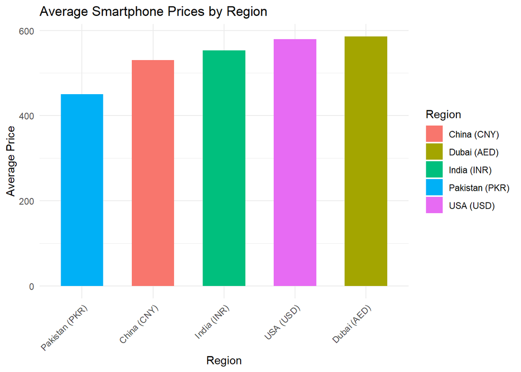

```r
library(dplyr)
library(ggplot2)
library(tidyr)

region_avg_prices <- mobiles_dataset %>%
  summarise(
    Avg_Price_PKR = mean(Launched.Price.Pakistan.PKR, na.rm = TRUE),
    Avg_Price_INR = mean(Launched.Price.India.INR, na.rm = TRUE),
    Avg_Price_CNY = mean(Launched.Price.China.CNY, na.rm = TRUE),
    Avg_Price_USD = mean(Launched.Price.USA.USD, na.rm = TRUE),
    Avg_Price_AED = mean(Launched.Price.Dubai.AED, na.rm = TRUE)
  ) %>%
  pivot_longer(cols = everything(), names_to = "Region", values_to = "Avg_Price") %>%
  mutate(Region = recode(Region,
                         "Avg_Price_PKR" = "Pakistan (PKR)",
                         "Avg_Price_INR" = "India (INR)",
                         "Avg_Price_CNY" = "China (CNY)",
                         "Avg_Price_USD" = "USA (USD)",
                         "Avg_Price_AED" = "Dubai (AED)"))

ggplot(region_avg_prices, aes(x = reorder(Region, Avg_Price), y = Avg_Price, fill = Region)) +
  geom_bar(stat = "identity", width = 0.6) +
  labs(title = "Average Smartphone Prices by Region",
       x = "Region", y = "Average Price") +
  theme_minimal() +
  theme(axis.text.x = element_text(angle = 45, hjust = 1))
```

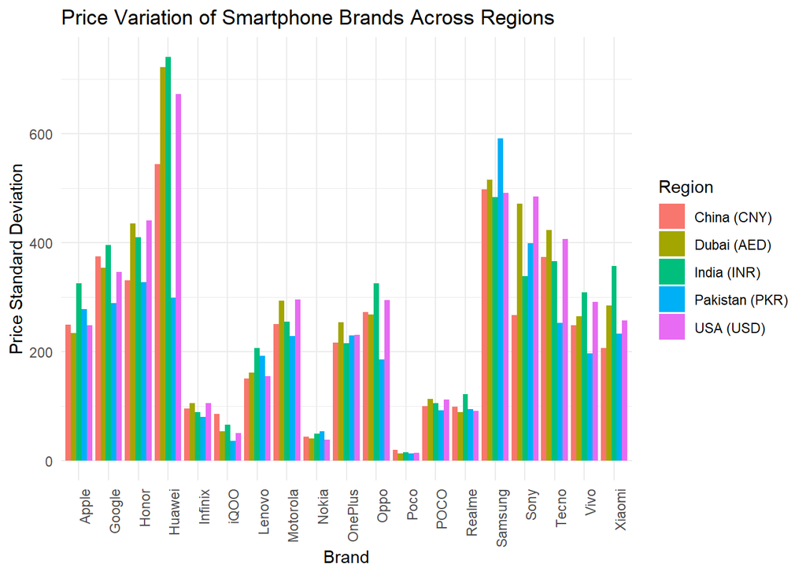

```r
brand_price_variation <- mobiles_dataset %>%
  group_by(Company.Name) %>%
  summarise(
    Price_SD_PKR = sd(Launched.Price.Pakistan.PKR, na.rm = TRUE),
    Price_SD_INR = sd(Launched.Price.India.INR, na.rm = TRUE),
    Price_SD_CNY = sd(Launched.Price.China.CNY, na.rm = TRUE),
    Price_SD_USD = sd(Launched.Price.USA.USD, na.rm = TRUE),
    Price_SD_AED = sd(Launched.Price.Dubai.AED, na.rm = TRUE)
  ) %>%
  pivot_longer(cols = -Company.Name, names_to = "Region", values_to = "Price_SD") %>%
  mutate(Region = recode(Region,
                         "Price_SD_PKR" = "Pakistan (PKR)",
                         "Price_SD_INR" = "India (INR)",
                         "Price_SD_CNY" = "China (CNY)",
                         "Price_SD_USD" = "USA (USD)",
                         "Price_SD_AED" = "Dubai (AED)"))
ggplot(brand_price_variation, aes(x = Company.Name, y = Price_SD, fill = Region)) +
  geom_bar(stat = "identity", position = "dodge") +
  labs(title = "Price Variation of Smartphone Brands Across Regions",
       x = "Brand", y = "Price Standard Deviation") +
  theme_minimal() +
  theme(axis.text.x = element_text(angle = 90, hjust = 1))
```

From the first bar chart (Average Smartphone Prices by Region), Pakistan (PKR) has the lowest average smartphone prices compared to other regions.SO Most Affordable: Pakistan China India USA Least Affordable: UAE

Thus, Pakistan offers the most affordable smartphone prices on average.

Conclusion: Pakistan has the most affordable smartphones on average. Huawei, Honor, and Samsung exhibit large price variations across regions, meaning they sell their phones at significantly different prices in different countries. Apple and Google maintain more stable pricing across regions.

Part 2: Visualization ( R)

1. Plot a bar chart for average price per region in USD.

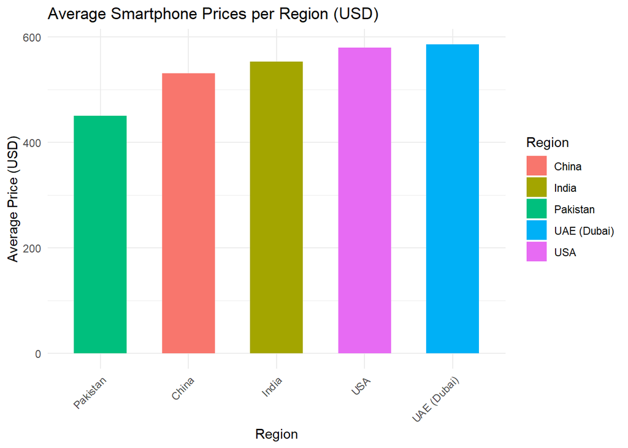

```r
library(dplyr)
library(ggplot2)

region_avg_prices <- data.frame(
  Region = c("Pakistan", "India", "China", "USA", "UAE (Dubai)"),
  Avg_Price = c(
    mean(mobiles_dataset$Launched.Price.Pakistan.PKR, na.rm = TRUE),
    mean(mobiles_dataset$Launched.Price.India.INR, na.rm = TRUE) ,
    mean(mobiles_dataset$Launched.Price.China.CNY, na.rm = TRUE) ,
    mean(mobiles_dataset$Launched.Price.USA.USD, na.rm = TRUE),
    mean(mobiles_dataset$Launched.Price.Dubai.AED, na.rm = TRUE)
  )
)

ggplot(region_avg_prices, aes(x = reorder(Region, Avg_Price), y = Avg_Price, fill = Region)) +
  geom_bar(stat = "identity", width = 0.6) +
  labs(title = "Average Smartphone Prices per Region (USD)",
       x = "Region", y = "Average Price (USD)") +
  theme_minimal() +
  theme(axis.text.x = element_text(angle = 45, hjust = 1))
```

2. Create a pie chart of the market share of smartphone brands

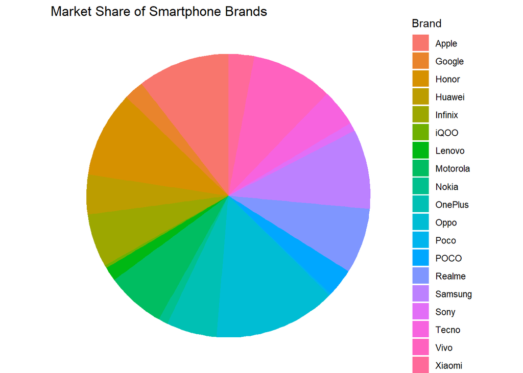

```r
brand_market_share <- as.data.frame(table(mobiles_dataset$Company.Name))

ggplot(brand_market_share, aes(x = "", y = Freq, fill = Var1)) +
  geom_bar(stat = "identity", width = 1) +
  coord_polar("y") +
  theme_void() +
  labs(title = "Market Share of Smartphone Brands", fill = "Brand")
```

Part 3: Recreate (R only)

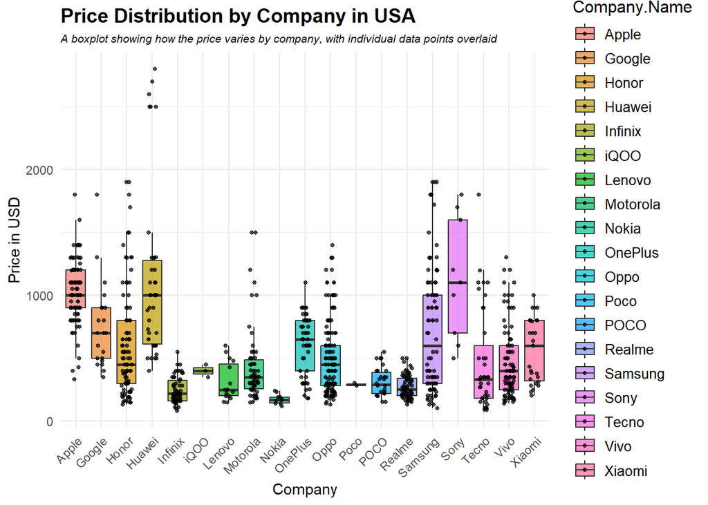

```r
mobiles_dataset$Company.Name <- as.factor(mobiles_dataset$Company.Name)

ggplot(mobiles_dataset, aes(x = Company.Name, y = Launched.Price.USA.USD, fill = Company.Name)) +
  geom_boxplot(outlier.shape = NA, alpha = 0.7) +
  geom_jitter(width = 0.2, alpha = 0.7, color = "black", size = 1) +
  theme_minimal() +
  labs(
    title = "Price Distribution by Company in USA",
    subtitle = "A boxplot showing how the price varies by company, with individual data points overlaid",
    x = "Company",
    y = "Price in USD"
  ) +
  theme(
    plot.title = element_text(face = "bold", size = 14),
    plot.subtitle = element_text(face = "italic", size = 8),
    axis.text.x = element_text(angle = 45, hjust = 1),
    legend.title = element_text(size = 12),
    legend.text = element_text(size = 10)
  )
```

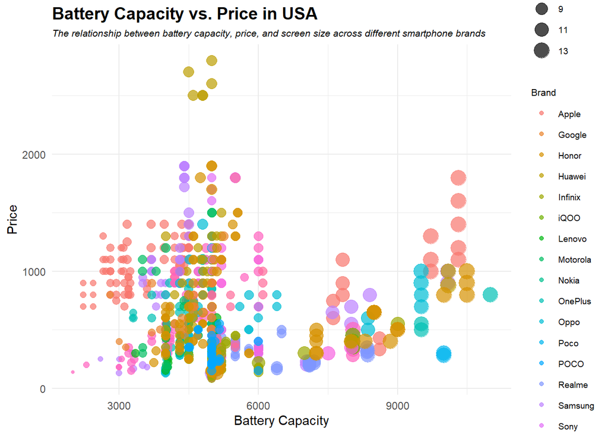

```r
mobiles_dataset$Company.Name <- as.factor(mobiles_dataset$Company.Name)
ggplot(mobiles_dataset, aes(x = Battery.Capacity.mAh,
                            y = Launched.Price.USA.USD,
                            color = Company.Name,
                            size = Screen.Size.inches)) +
  geom_point(alpha = 0.7) +
  theme_minimal() +
  labs(
    title = "Battery Capacity vs. Price in USA",
    subtitle = "The relationship between battery capacity, price, and screen size across different smartphone brands",
    x = "Battery Capacity",
    y = "Price",
    color = "Brand",
    size = "Screen Size"
  ) +
  theme(
    plot.title = element_text(face = "bold", size = 14),
    plot.subtitle = element_text(face = "italic", size = 8),
    axis.text.x = element_text(angle = 0),
    legend.title = element_text(size = 8),
    legend.text = element_text(size = 7),
    legend.position = "right"
  )
```

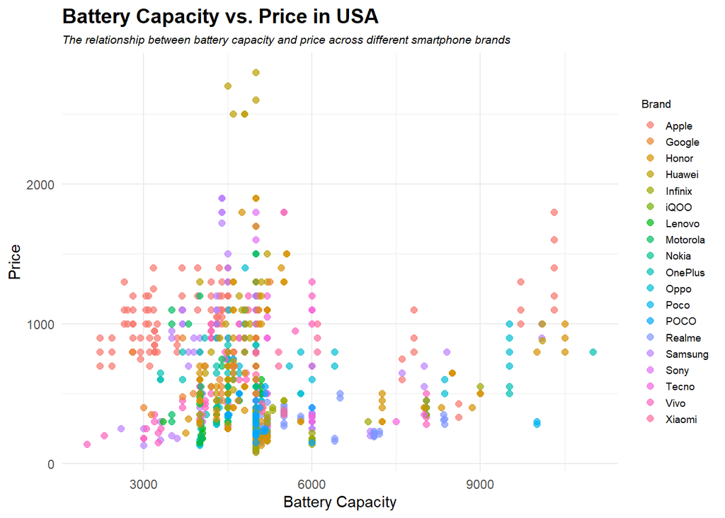

```r
mobiles_dataset$Company.Name <- factor(mobiles_dataset$Company.Name)


ggplot(mobiles_dataset, aes(x = Battery.Capacity.mAh,
                            y = Launched.Price.USA.USD,
                            color = Company.Name)) +
  geom_point(alpha = 0.7, size = 2) +
  theme_minimal() +
  labs(
    title = "Battery Capacity vs. Price in USA",
    subtitle = "The relationship between battery capacity and price across different smartphone brands",
    x = "Battery Capacity",
    y = "Price",
    color = "Brand"
  ) +
  scale_color_manual(values = scales::hue_pal()(length(levels(mobiles_dataset$Company.Name)))) +
  theme(
    plot.title = element_text(face = "bold", size = 14),
    plot.subtitle = element_text(face = "italic", size = 8),
    axis.text.x = element_text(angle = 0),
    legend.title = element_text(size = 8),
    legend.text = element_text(size = 7),
    legend.position = "right",
    legend.key.size = unit(0.4, "cm")
  ) +
  guides(color = guide_legend(ncol = 1))
```

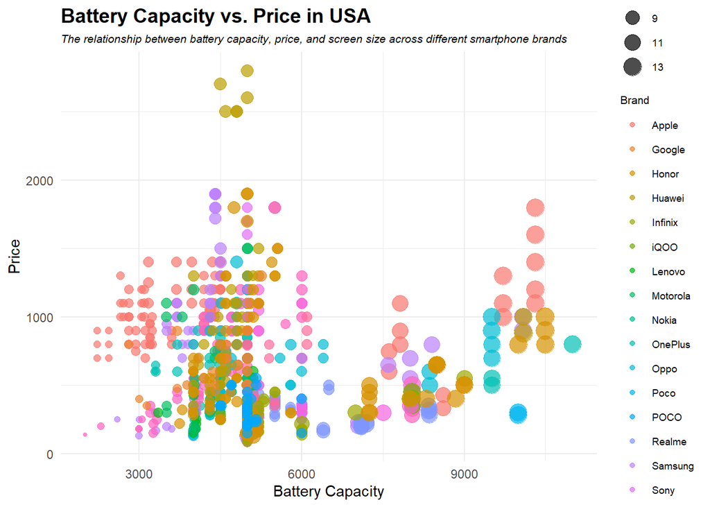

```r
mobiles_dataset$Company.Name <- factor(mobiles_dataset$Company.Name)

ggplot(mobiles_dataset, aes(x = Battery.Capacity.mAh,
                            y = Launched.Price.USA.USD,
                            color = Company.Name,
                            size = Screen.Size.inches)) +
  geom_point(alpha = 0.7) +
  scale_size_continuous(range = c(1, 6), guide = "legend") +
  scale_color_manual(values = scales::hue_pal()(length(levels(mobiles_dataset$Company.Name)))) +
  theme_minimal() +
  labs(
    title = "Battery Capacity vs. Price in USA",
    subtitle = "The relationship between battery capacity, price, and screen size across different smartphone brands",
    x = "Battery Capacity",
    y = "Price",
    color = "Brand",
    size = "Screen Size"
  ) +
  theme(
    plot.title = element_text(face = "bold", size = 14),
    plot.subtitle = element_text(face = "italic", size = 8),
    axis.text.x = element_text(angle = 0),
    legend.title = element_text(size = 8),
    legend.text = element_text(size = 7),
    legend.position = "right",
    legend.spacing.y = unit(0.01, 'mm')
  ) +
  guides(color = guide_legend(ncol = 1))
```

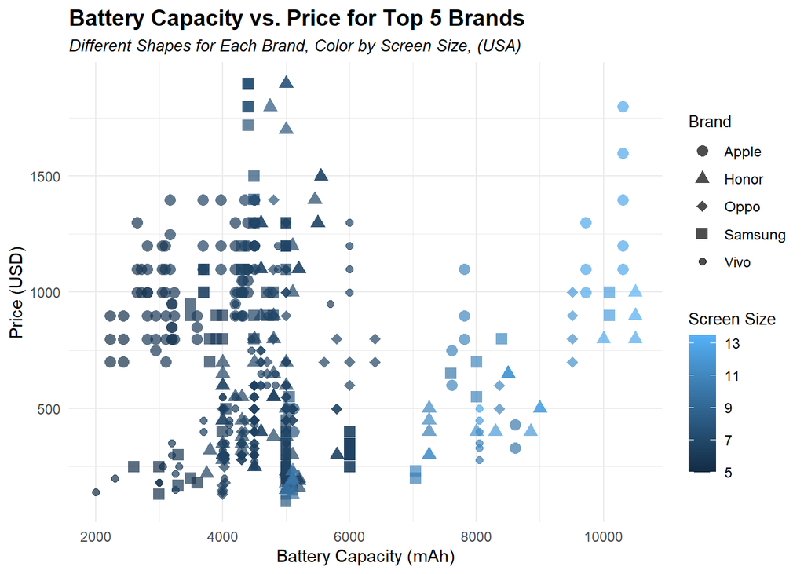

```r
library(ggplot2)
library(dplyr)

top_brands <- c("Apple", "Honor", "Oppo", "Samsung", "Vivo")
filtered_data <- mobiles_dataset %>%
  filter(Company.Name %in% top_brands)

filtered_data$Company.Name <- factor(filtered_data$Company.Name, levels = top_brands)

ggplot(filtered_data, aes(x = Battery.Capacity.mAh,
                          y = Launched.Price.USA.USD,
                          shape = Company.Name,
                          color = Screen.Size.inches)) +
  geom_point(alpha = 0.7, size = 3) +
  scale_shape_manual(values = c(16, 17, 18, 15, 20)) +
  theme_minimal() +
  labs(
    title = "Battery Capacity vs. Price for Top 5 Brands",
    subtitle = "Different Shapes for Each Brand, Color by Screen Size, (USA)",
    x = "Battery Capacity (mAh)",
    y = "Price (USD)",
    color = "Screen Size",
    shape = "Brand"
  ) +
  theme(
    plot.title = element_text(face = "bold", size = 14),
    plot.subtitle = element_text(face = "italic", size = 10),
    axis.text.x = element_text(angle = 0),
    legend.title = element_text(size = 10),
    legend.text = element_text(size = 9),
    legend.position = "right"
  )
```

Part 4: Personal findings Using either R or Python, explain what else affects the prices of mobile phones. Summarize your findings.

```r
library(ggplot2)
library(dplyr)
library(corrplot)

df <- mobiles_dataset

df$RAM <- as.numeric(gsub("GB", "", df$RAM))
df$Front.Camera <- as.numeric(gsub("MP", "", df$Front.Camera))
df$Back.Camera <- as.numeric(gsub("MP", "", df$Back.Camera))
df$Processor <- as.factor(df$Processor)
df$Company.Name <- as.factor(df$Company.Name)

numeric_data <- df %>% select(Launched.Price.USA.USD, Battery.Capacity.mAh, Screen.Size.inches, RAM, Front.Camera, Back.Camera)

numeric_data <- na.omit(numeric_data)
```

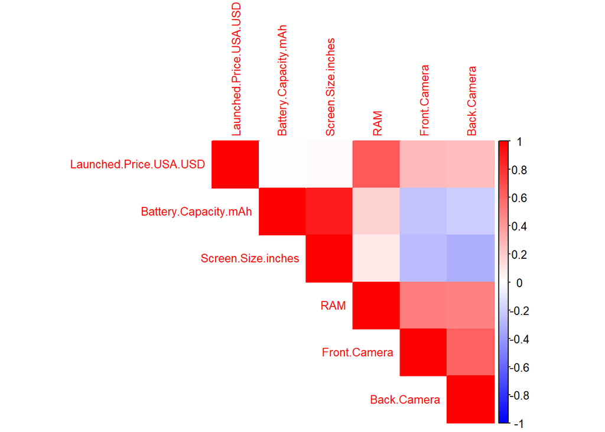

```r
cor_matrix <- cor(numeric_data, use = "complete.obs")
corrplot(cor_matrix, method = "color", type = "upper", tl.cex = 0.8, number.cex = 0.8, col = colorRampPalette(c("blue", "white", "red"))(200))
```

```r
model <- lm(Launched.Price.USA.USD ~ Battery.Capacity.mAh + Screen.Size.inches + RAM + Front.Camera + Back.Camera + Company.Name + Processor, data = df)
summary(model)
```

```
##
## Call:
## lm(formula = Launched.Price.USA.USD ~ Battery.Capacity.mAh +
##     Screen.Size.inches + RAM + Front.Camera + Back.Camera + Company.Name +
##     Processor, data = df)
##
## Residuals:
##     Min      1Q  Median      3Q     Max
## -640.47  -47.62    0.00   43.23 1132.55
##
## Coefficients: (1 not defined because of singularities)
##                                         Estimate Std. Error t value
## (Intercept)                            334.51510  138.23387   2.420
## Battery.Capacity.mAh                    -0.10219    0.02391  -4.273
## Screen.Size.inches                      64.75321   19.66430   3.293
## RAM                                     36.31030    5.97772   6.074
## Front.Camera                             2.65558    1.43548   1.850
## Back.Camera                             -0.12312    0.48502  -0.254
## Company.NameGoogle                      43.73968  245.02210   0.179
## Company.NameHonor                     -341.34823  174.01811  -1.962
## Company.NameHuawei                    -381.36149  262.67171  -1.452
## Company.NameInfinix                   -403.04331  174.20154  -2.314
## Company.NameiQOO                      -383.81607  204.02630  -1.881
## Company.NameLenovo                    -395.51122  182.86501  -2.163
## Company.NameMotorola                  -287.92243  164.71963  -1.748
## Company.NameNokia                     -299.51911  193.74792  -1.546
## Company.NameOnePlus                   -257.76033  194.69048  -1.324
## Company.NameOppo                      -125.37464  189.77874  -0.661
## Company.NamePoco                      -149.82105  223.10829  -0.672
## Company.NamePOCO                      -324.17149  174.45140  -1.858
## Company.NameRealme                    -260.58519  179.55785  -1.451
## Company.NameSamsung                   -215.30658  190.65539  -1.129
## Company.NameSony                       265.70285  183.37889   1.449
## Company.NameTecno                     -209.84102  176.38685  -1.190
## Company.NameVivo                      -340.85198  173.77976  -1.961
## ProcessorA13 Bionic                    124.21410  169.67735   0.732
## ProcessorA14 Bionic                    194.24263  136.52501   1.423
## ProcessorA15 Bionic                    188.31602  151.06898   1.247
## ProcessorA16 Bionic                    314.44231  134.79539   2.333
## ProcessorA17 Bionic                    304.77019  134.61769   2.264
```

[output cut: 333 more lines]

```
## ProcessorUnisoc SC9832E                         0.696722
## ProcessorUnisoc SC9863A                         0.791980
## ProcessorUnisoc T606                            0.461042
## ProcessorUnisoc T610                            0.361656
## ProcessorUnisoc T616                            0.769759
## ProcessorUnisoc T618                            0.863357
## ProcessorUnisoc T700                            0.433412
## ProcessorUnisoc T760                                  NA
## ---
## Signif. codes:  0 '***' 0.001 '**' 0.01 '*' 0.05 '.' 0.1 ' ' 1
##
## Residual standard error: 162.2 on 322 degrees of freedom
##   (420 observations deleted due to missingness)
## Multiple R-squared:  0.8807, Adjusted R-squared:  0.8132
## F-statistic: 13.06 on 182 and 322 DF,  p-value: < 0.00000000000000022
```

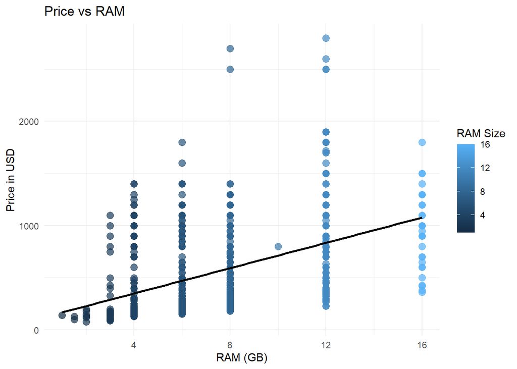

```r
ggplot(df, aes(x = RAM, y = Launched.Price.USA.USD, color = RAM)) +
  geom_point(alpha = 0.7, size = 3) +
  geom_smooth(method = "lm", se = FALSE, color = "black") +
  theme_minimal() +
  labs(title = "Price vs RAM",
       x = "RAM (GB)",
       y = "Price in USD",
       color = "RAM Size")
```

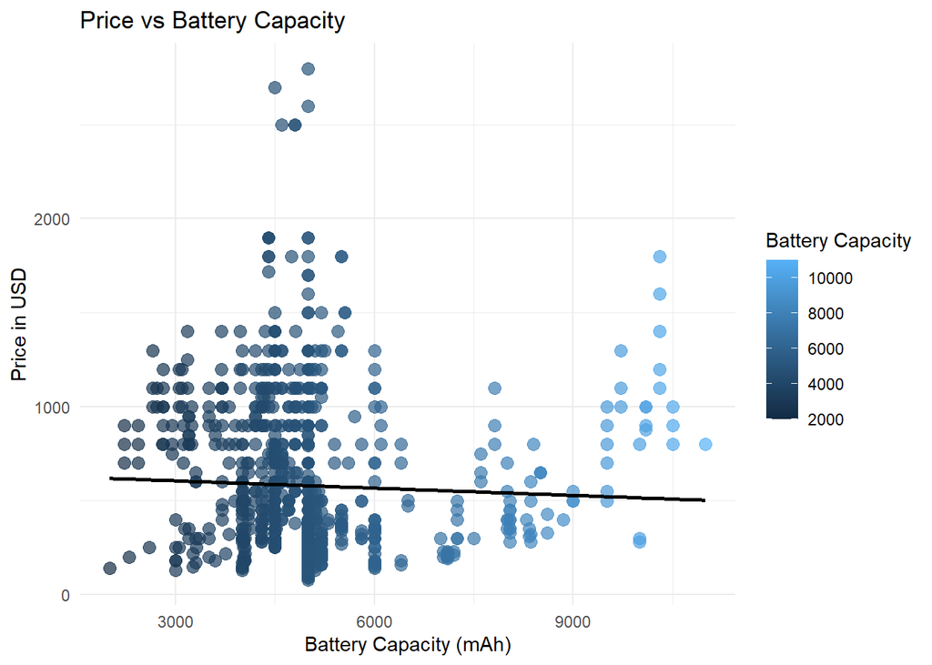

```r
ggplot(df, aes(x = Battery.Capacity.mAh, y = Launched.Price.USA.USD, color = Battery.Capacity.mAh)) +
  geom_point(alpha = 0.7, size = 3) +
  geom_smooth(method = "lm", se = FALSE, color = "black") +
  theme_minimal() +
  labs(title = "Price vs Battery Capacity",
       x = "Battery Capacity (mAh)",
       y = "Price in USD",
       color = "Battery Capacity")
```

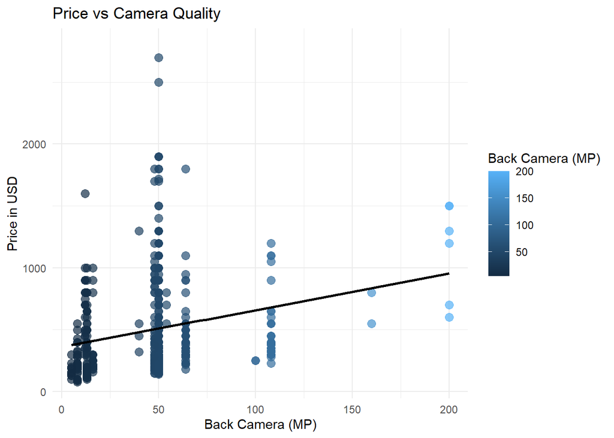

```r
ggplot(df, aes(x = Back.Camera, y = Launched.Price.USA.USD, color = Back.Camera)) +
  geom_point(alpha = 0.7, size = 3) +
  geom_smooth(method = "lm", se = FALSE, color = "black") +
  theme_minimal() +
  labs(title = "Price vs Camera Quality",
       x = "Back Camera (MP)",
       y = "Price in USD",
       color = "Back Camera (MP)")
```